# Netflix Prize Data Project: Preliminary Analyses

Caitlyn Ralph

4/18/2018

# Outline:

1. Load in and view the data.
2. Label Ratings as positive or negative (dummy variable).
3. Split in between test and training data.
4. List out models that will be used and write out code to train on training set.
5. Report and summarize preliminary results (which models are producing the lowest test error?)

## 1. Load in and view the data.

```r
# load library
library(tidyverse)

# load in large sample dataset
sample_data <- read_csv("ratings_1_sample.csv")

# Sample only 500 movies.

# extract movieID column
movieID <- as.vector(sample_data$MovieID)
# get only unique movie IDs
unique_movieID <- unique(movieID)
# sample 500 unique movie IDs
set.seed(1)
movieID_sample <- sample(unique_movieID,500, replace=F)
# new data frame, remove and store rows with movie ID in movieID_sample
sample_data2 <- sample_data[ sample_data$MovieID %in% movieID_sample, ]
# check number of unique movie IDs (should be 500)
unique_movieID2 <- unique(sample_data2$MovieID)

# Lastly, I'm going to drop the Date row for the time being.
ratings <- subset(sample_data2, select = c("X1","CustomerID","Rating","MovieID","MovieTitle"))
```

## 2. Convert Ratings to categorical variable.

```r
# Convert all 1 and 2 ratings to 0 and convert all 3, 4, and 5 ratings to 1.

# set minvalue
minval<-4
ratings$Rating[ratings$Rating<minval]=0
ratings$Rating[ratings$Rating>=minval]=1
```

## 3. Split in between test and training data.

```r
train <- sample(dim(ratings)[1], dim(ratings)[1]/2)
ratings.train <- ratings[train,]
ratings.test <- ratings[-train,]
rating.test <- ratings$Rating[-train]
```

## 4. List out models that will be used and write out code to train on training set.

Models: - Logistic Regression, LDA, K-Nearest Neighbors (Chapter 4) - Classification Trees (Chapter 8) - SVM (Chapter 9) - Additionally, if these are not performing well, I can look into some non-linear models (Chapter 7) for classification, such as GAMs.

```r
# get a feel for the data
summary(ratings)
```

```
##        X1           CustomerID          Rating          MovieID
##  Min.   :   253   Min.   :    265   Min.   :0.0000   Min.   :   9
##  1st Qu.: 41436   1st Qu.: 668669   1st Qu.:0.0000   1st Qu.:1150
##  Median : 76310   Median :1330878   Median :0.0000   Median :2194
##  Mean   : 81285   Mean   :1333560   Mean   :0.4314   Mean   :2234
##  3rd Qu.:122154   3rd Qu.:1991147   3rd Qu.:1.0000   3rd Qu.:3238
##  Max.   :160992   Max.   :2649308   Max.   :1.0000   Max.   :4484
##   MovieTitle
##  Length:17857
##  Class :character
##  Mode  :character
##
##
##
```

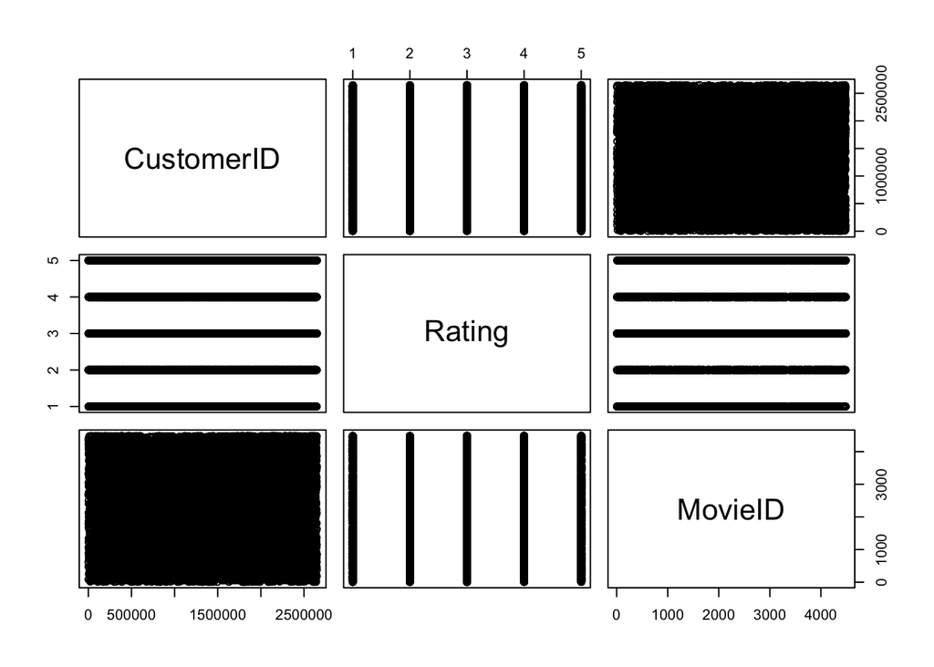

```r
pairs(subset(sample_data2, select = c("CustomerID","Rating","MovieID")))
```

```r
cor(subset(sample_data2, select = c("CustomerID","Rating","MovieID")))
```

```
##            CustomerID      Rating     MovieID
## CustomerID 1.00000000  0.00941709  0.01035548
## Rating     0.00941709  1.00000000 -0.01524888
## MovieID    0.01035548 -0.01524888  1.00000000
```

At this moment, I’m not seeing much correlation between the variables. The largest correlation I’m seeing is between MovieID and Rating.

```r
# generalized linear model on training data
glm.fit <- glm(Rating~MovieID,data=ratings.train,family=binomial)
glm.probs<-predict(glm.fit,newdata=ratings.test,type="response")
glm.pred<-rep(1,17857)
glm.pred[glm.probs>0.5]=1
mean(glm.pred == rating.test)
```

```
## [1] 0.4259394
```

```r
library(MASS)
lda.fit<-lda(Rating~MovieID,data=ratings,subset=train)
lda.pred<-predict(lda.fit,ratings.test)
mean(lda.pred$class != rating.test)
```

```
## [1] 0.4259156
```

```r
qda.fit<-qda(Rating~MovieID,data=ratings,subset=train)
qda.pred<-predict(qda.fit,ratings.test)
mean(qda.pred$class!=rating.test)
```

```
## [1] 0.4259156
```

I’m having some trouble with the code below for KNN. The error is telling me that the dimensions of train.X and test.Y are different, and I’m not sure why.

```
library(class)
train.X<-ratings$MovieID[train]
test.X<-ratings$MovieID[-train]
train.rating<-ratings$Rating[train]
kmn.pred<-knn(train.X,test.X,train.rating,k=3)
table(knn.pred,ratings$Rating)
```

```r
library(tree)
Rating1 <- ifelse(ratings$Rating==1,"Yes","No")
ratings<-data.frame(ratings,Rating1)
fit.tree<-tree(Rating1~MovieID,ratings[train,])
summary(fit.tree)
```

```
##
## Classification tree:
## tree(formula = Rating1 ~ MovieID, data = ratings[train, ])
## Variables actually used in tree construction:
## character(0)
## Number of terminal nodes:  1
## Residual mean deviance:  1.37 = 12230 / 8927
## Misclassification error rate: 0.4369 = 3901 / 8928
```

```r
Rating1.test<-ratings$Rating1[-train]
tree.pred<-predict(fit.tree,ratings[-train,],type="class")
table(tree.pred,Rating1.test)
```

```
##          Rating1.test
## tree.pred   No  Yes
##       No  5126 3803
##       Yes    0    0
```

```r
(5165+0)/17857
```

```
## [1] 0.2892423
```

Unfortunately, I set up the code for the support vector classifier (see below), but it was taking a really long time to run and R was crashing (dataset too large?).

```
set.seed(1)
library(e1071)
svm.fit<-svm(Rating~MovieID,data=ratings.train,kernel="linear",cost=0.001,scale=FALSE)
```